[figure not shown]

Player Development

Research

# Defensive Run Value Level Translations

What minor league defensive numbers tell us about the next level.

Author

Inaki Sardina

Published

October 10, 2026

By Inaki Sardina October 10, 2026 SFG defensive run value · 2021–2026 Games through August 21, 2026

## Project Summary

A player’s defensive numbers shrink with every promotion, but where they rank among their peers holds up. Good defenders in the minors usually become good defenders in the majors.

- **0.30** runs: a one-run advantage in FRV/100 at one level corresponds to approximately a 0.30-run advantage at the next level, on average (0.32 for catcher framing).
- **67%** of top-20% position players stay above average after moving up (71% of top-20% framers).
- **72%** of today’s above-average MLB position players were above average in the minors (85% of framers).
- **16%** of the difference in catchers’ season value comes from throwing, with framing the rest.

## Introduction

When a player moves up a level, how much of their defensive value comes with them? This report answers that using SFG defensive run value from rookie ball through MLB.

**Project Questions:**

1. How do defensive numbers change as players move up the ladder?
2. How much of a player’s defense at one level shows up at the next?
3. How do catching skills translate across levels?

**How to read the numbers:**

- **Runs saved per 100 chances** measures a player’s defense. 0 is average, positive is better than average, negative is worse. For position players a chance is a ball in play they could make a play on; for catchers chances are called pitches and basestealing throwing opportunities.
- **Rank among peers** compares a player only with others at the same level, in the same season, at the same position. A player at 80% ranks ahead of 80% of their peers.

## Position Players

### Rookie-ball numbers swing much more

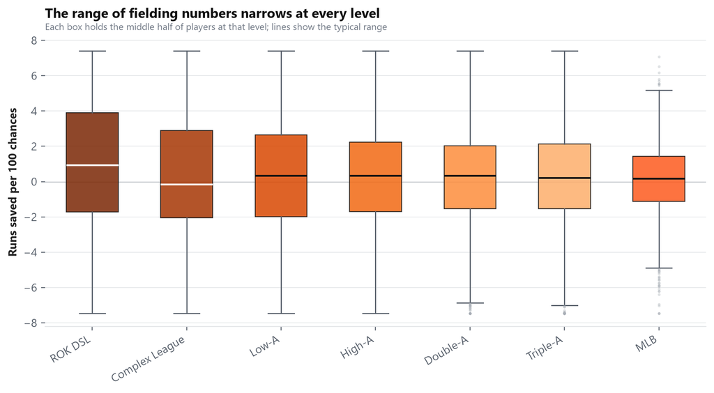

Rookie-ball fielding numbers are spread much wider than MLB numbers. The range covering most players (the middle 80%) is 2.3 times as wide in ROK DSL as it is in MLB. Players get fewer chances in rookie ball, talent is more uneven and tracking systems are less reliable, so big numbers in either direction are more common and “mean” less.

### Only part of a player’s edge moves up with them

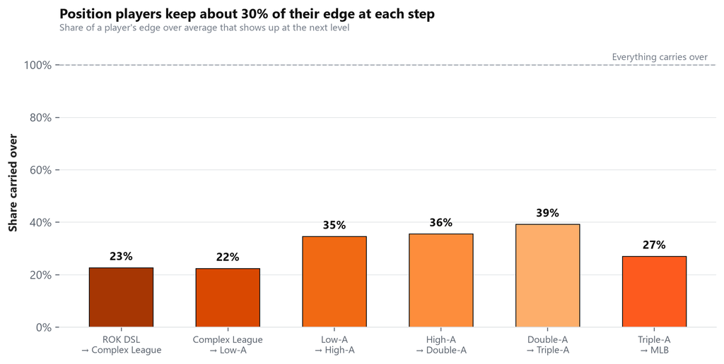

When a position player moves up a level, only about 30% of their edge over an average player shows up at the next level. For every 10 runs above average at one level, expect roughly 3 above average at the next. The pattern holds at every step, from Rookie Ball to Triple-A to MLB.

### Where a player ranks carries forward

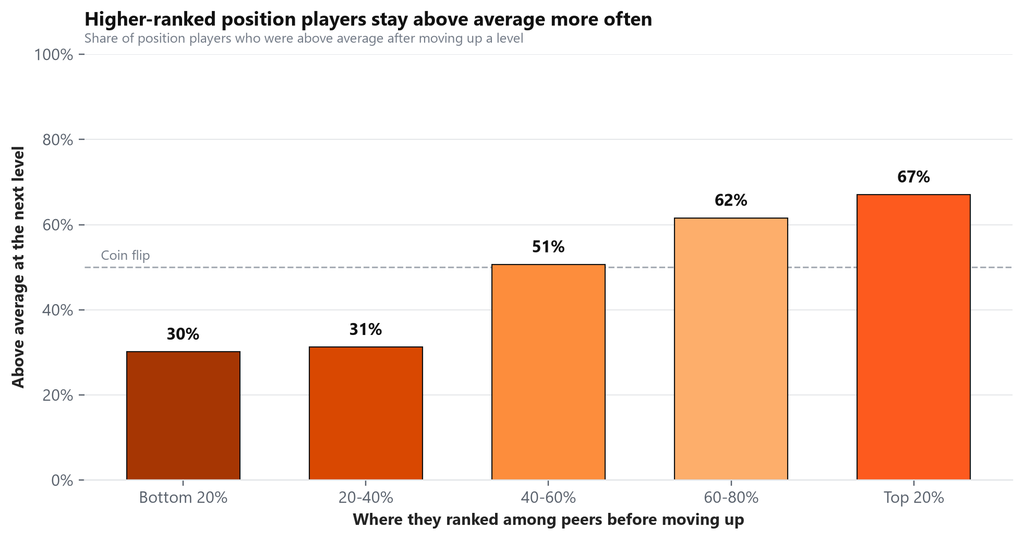

**How to read this chart:** position players are sorted into five groups by where they ranked among their peers before a promotion, from the bottom 20% on the left to the top 20% on the right. Each bar shows how many in that group were **above average at the next level**. If rank meant nothing, every bar would sit near the 50% line, like a coin flip.

Instead, the bars climb from left to right. Position players in the top 20% are above average after moving up 67% of the time, while position players in the bottom 20% get there only 30% of the time. Even though the raw numbers shrink, a player’s rank holds up.

### Do poor position players still move up?

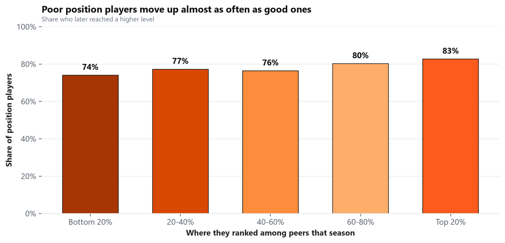

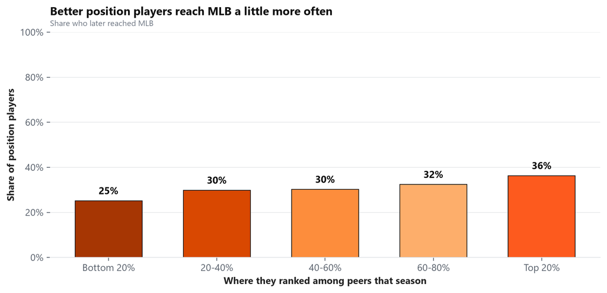

Yes, most of them do. Looking at minor-league seasons through 2024 (so every player has had at least two more seasons to move up), position players who ranked in the bottom 20% at their level still moved up at least one level 74% of the time, compared with 83% for the top 20%. 25% of bottom-20% position players eventually reached MLB, compared with 36% of the top 20%.

Defensive performance is associated with promotion rates, but it is not the sole determining factor. Players with below-average defense frequently advance to higher levels, where their defensive struggles can persist.

### Today’s good MLB position players were good in the minors

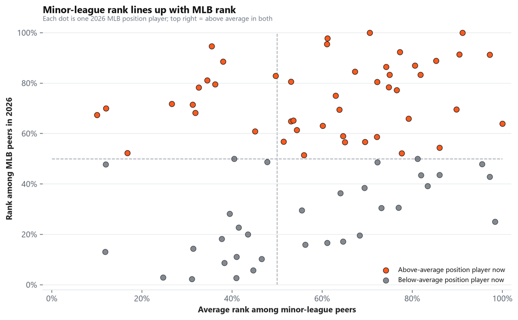

Looking back at 2026 MLB position players who came up through the minors recently, 72% of the above-average ones were also above average in the minors. A good minor-league track record doesn’t guarantee a good MLB defender, but it improves the odds.

The six best and six worst of those MLB position players this season, and how they ranked at each stop on the way up:

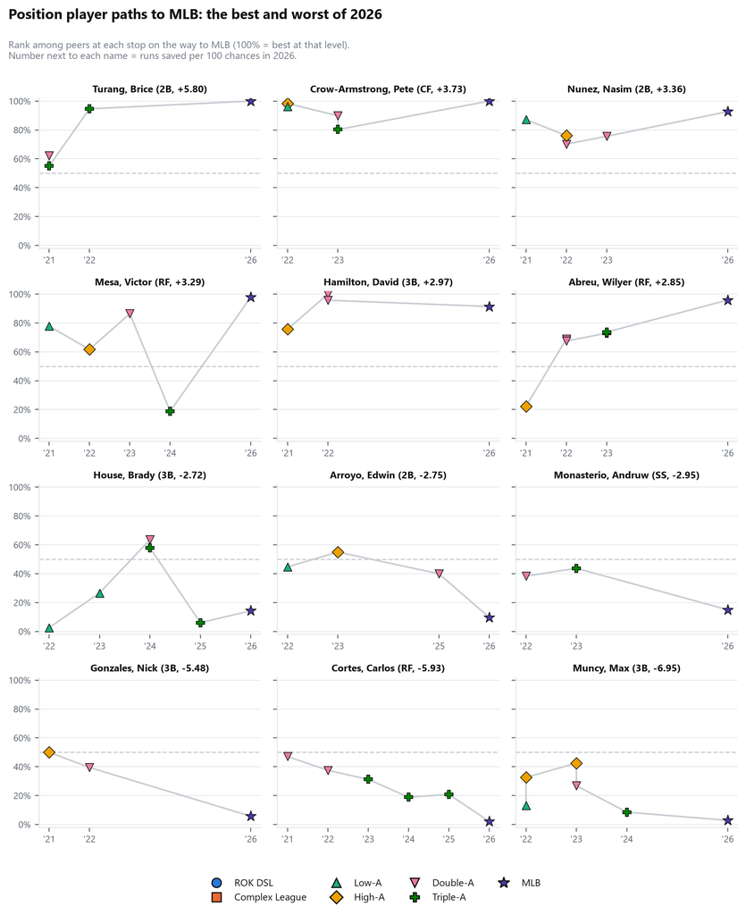

### Age: position players keep pace until their late 20s

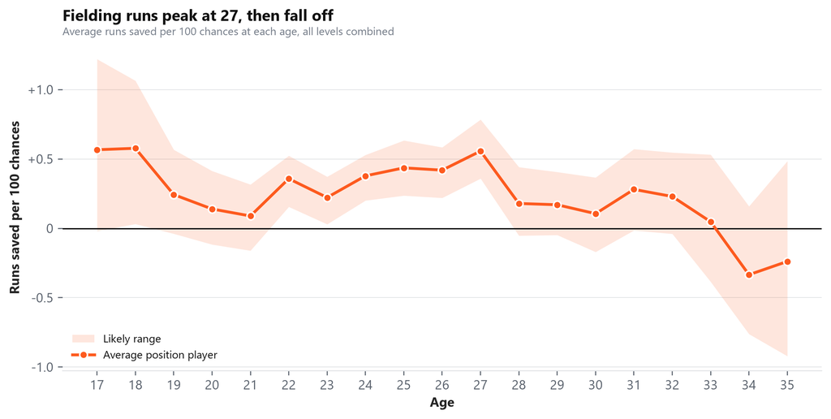

**Runs saved at each age.** First, the plain numbers: the average runs saved per 100 chances for position players at each age, across all levels.

- **Building up:** after a low point at 21 (+0.09 runs per 100 chances), fielding runs climb to a peak of +0.56 at age 27.
- **Falling off:** from 28 on, the average drops to +0.14, and by 34 the typical position player is below zero.
- **The youngest ages** (17–18) look strong too, but most of those seasons are in rookie ball, where numbers swing the most.

Players of the same age are spread across different levels, so this chart mixes getting older with who is playing where. The next chart handles that by comparing each player only with peers at their own level.

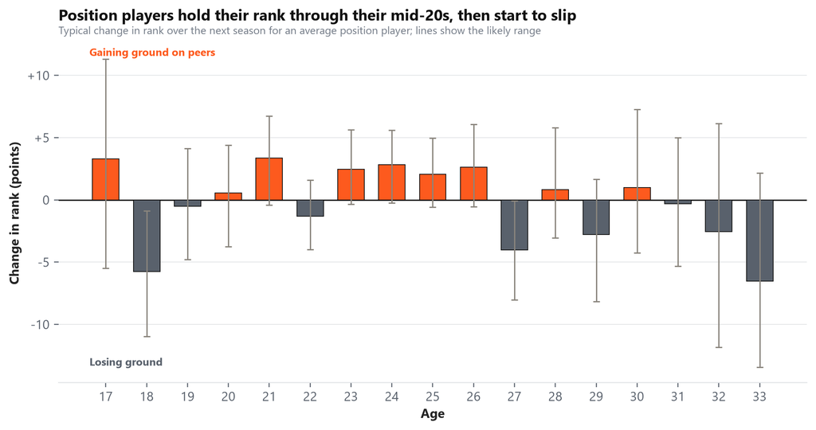

**Keeping pace with peers.** This chart asks how a position player’s **rank among their peers** changes from one season to the next as they get older. Because rank is measured against players at the same level, players can be followed even when they move up. Each bar is the typical change for an average position player at that age. Above zero means they gained ground on their peers over the next season; below zero means they lost ground.

- **Up to 26:** position players hold or slightly gain ground, about +1.3 rank points a season on average.
- **From 27:** they tend to slip, about -1.8 points a season, with the biggest drops in the early 30s.

The lines on each bar show how uncertain that single age is, and most of them cross zero. The pattern across ages is more reliable than any one bar.

### Position: players grade worse at harder spots

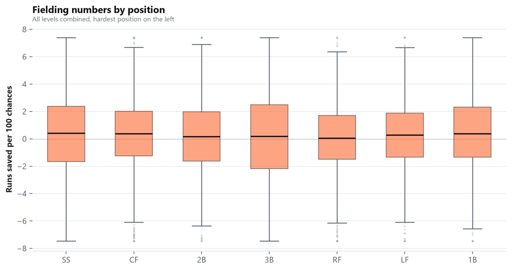

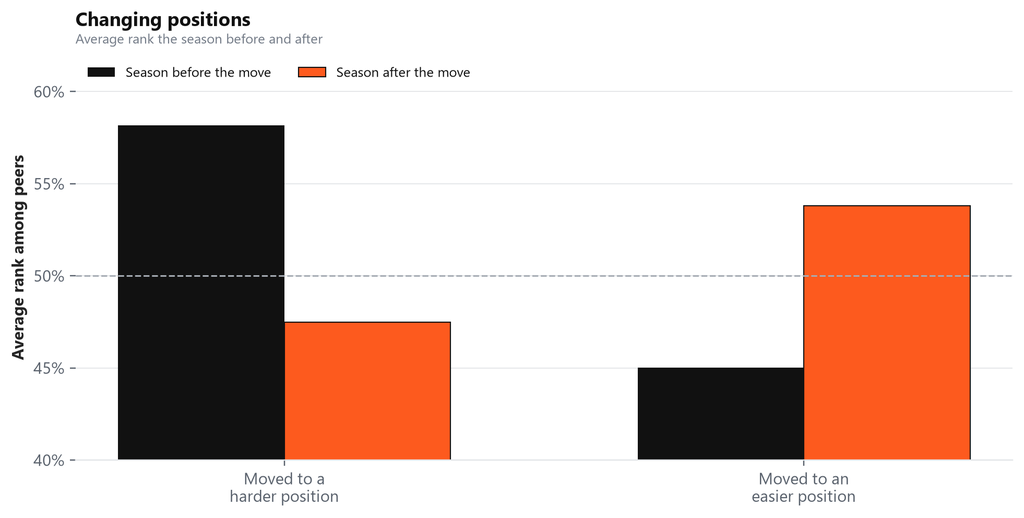

**Same player, two positions.** When a player played two positions in the same season and at the same level, they graded worse at the harder position 63% of the time. The biggest gap was between CF and RF.

**Changing positions.** Players who moved to an easier position ranked about 9 points higher the next season. Players who moved to a harder position ranked about 11 points lower.

### Position player takeaways

- Rookie-ball fielding numbers swing widely, so judge players against their peers at that level.
- Expect about 30% of a position player’s edge to carry to the next level.
- Rank carries forward: top-20% position players usually stay above average after moving up.
- Poor position players still get promoted most of the time, so their defensive problems move up with them.
- Position players keep pace with their peers through their mid-20s and start to slip from their late 20s.
- Position matters: expect a player’s grade to drop at a harder position and rise at an easier one.

## Catchers

Catchers generate most of their defensive value differently from other position players, primarily through **framing** and **throwing**. Throwing data covers 2016–2026 from Low-A to MLB.

### Framing matters most, but throwing counts too

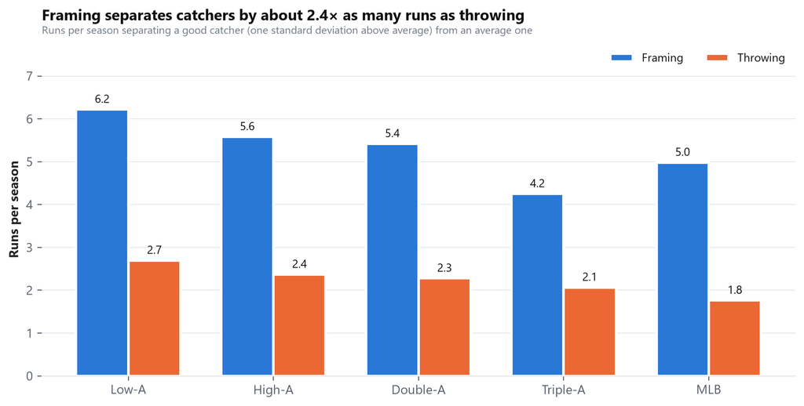

Framing happens on every pitch and throwing only on steal attempts, and over a season framing makes the bigger difference. A good framer (one standard deviation above average) saves about 5.0 runs a season in MLB, and a good thrower about 1.8. Across levels, throwing accounts for 11%–19% of the spread in catchers’ combined value, with framing the rest.

- **They’re separate skills.** A catcher’s framing and throwing runs are barely related (correlations of 0.02 to 0.15 by level), so a good framer isn’t necessarily a good thrower. Each needs its own look.

### Framing: the rank travels even when the number doesn’t

As with position players, framing numbers swing much more in rookie ball (the spread is 3.8 times as wide in ROK DSL as in MLB), and a catcher keeps only about 32% of their framing edge when they move up a level. The Run Value Translator below covers the numbers for any pair of levels. What stands out for catchers is how well **framing rank** holds up:

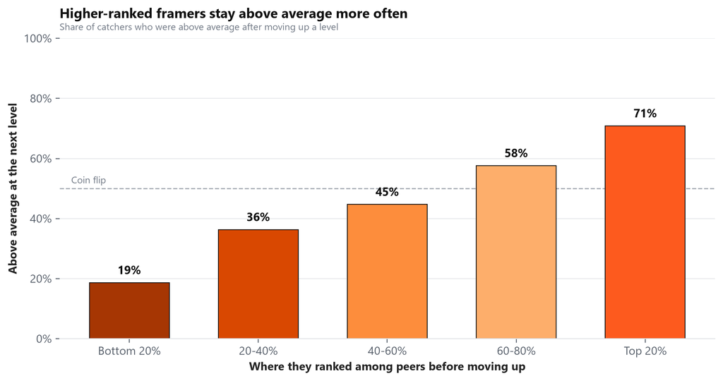

Catchers in the top 20% at their level are above average framers at the next level 71% of the time, and those in the bottom 20% only 19% of the time. That’s a wider gap than for position players (67% against 30%), making framing rank one of the steadiest signals in this report. It shows at the top too: 85% of today’s above-average MLB framers were above-average framers in the minors.

### Caught-stealing rates across levels

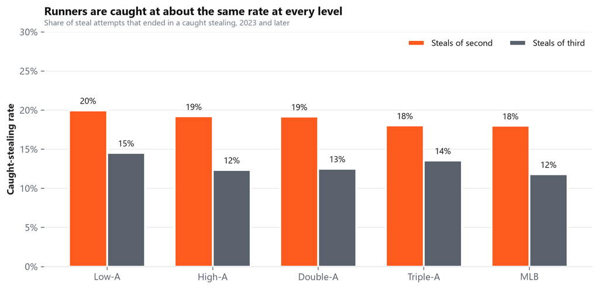

Since 2023, when MLB adopted the running-game rules already in use in the minors (bigger bases and limits on pickoffs), runners have been caught about as often at every level: 17%–19% of attempts.

- **Steals of second are caught far more often than steals of third:** 18%–20% against 12%–15%. Steals of third are rarer (15% of attempts), likely because runners are more cautious when attempting a steal of third.
- **The level doesn’t change the odds much,** even though pop times get quicker higher up (see below), suggesting runners may be more selective, attempting them only when success is more likely.

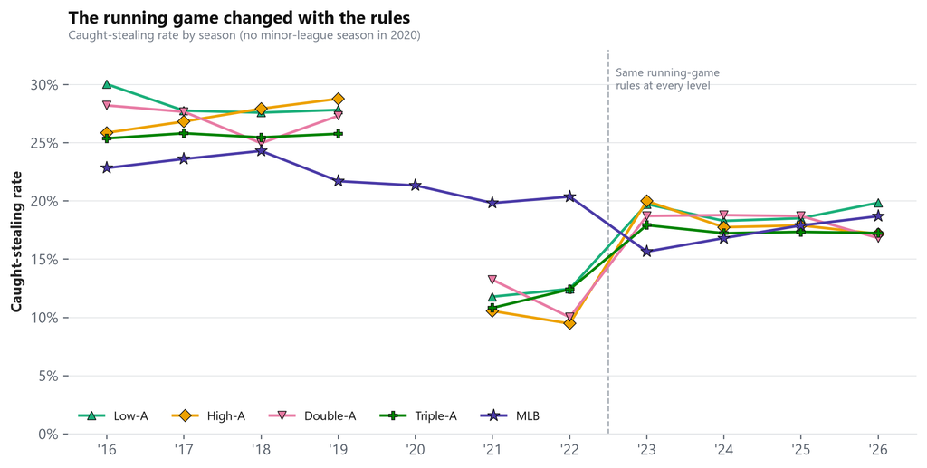

Over time, caught-stealing rates fell. Before 2020, minor-league runners were caught 27% of the time and MLB runners 23%; since 2023 it’s 18% in the minors and 17% in MLB. The 2021–2022 minor-league seasons, when the new rules were being tested, show unusually low rates (11%); treat those two seasons with care, since they may partly reflect how those games were recorded. Comparisons between levels in this section use 2023 and later.

### What decides a Successful Steal

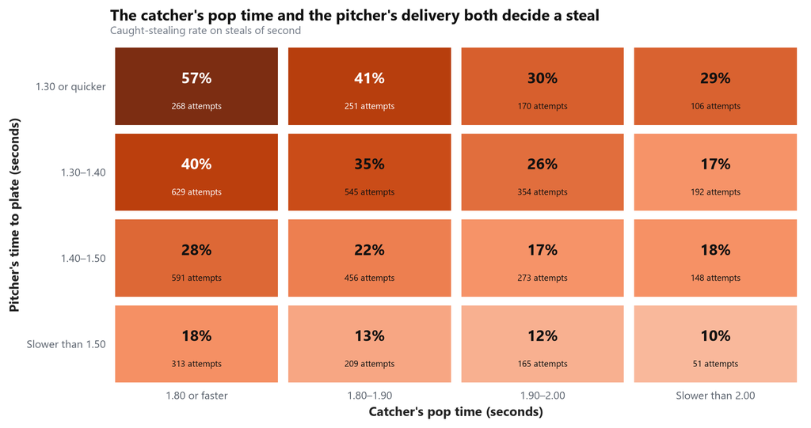

Each cell shows how often runners were caught stealing second, by the catcher’s pop time (across) and the pitcher’s time to the plate (down). A fast pop behind a quick pitcher throws out 57% of runners; a slow pop behind a slow pitcher, 10%.

Looking at the catcher’s pop time and arm strength, the pitcher’s delivery time and the runner’s speed together on the same attempts, a typical difference in each moves the caught-stealing rate by:

- **Pitcher’s time to the plate:** about 11 points for 0.10 s quicker, the biggest of the four.
- **Runner speed:** about 9 points for a runner 0.9 ft/s faster (in the runner’s favor).
- **Catcher’s pop time:** about 5 points for 0.13 s faster, or 4 points per tenth of a second.
- **Catcher’s arm strength:** about 5 points for a throw 3.3 mph harder, or about 1.4 points per mph.

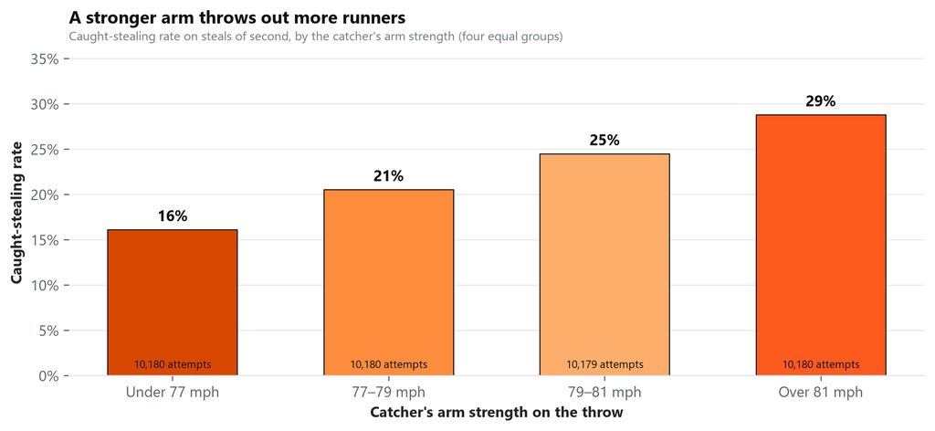

Arm strength and pop time are the two parts the catcher controls, and they’re related but not the same thing (correlation -0.35). Pop time also includes the transfer and footwork, so a catcher with a lighter arm can make up some ground with a quick release, and a strong arm can be wasted by a slow one. On the same throws, each is worth about the same. Catchers with the weakest arms throw out 16% of runners, against 29% for the strongest. Even so, the pitcher’s delivery matters at least as much as either.

### Part of a catcher’s throwing value belongs to the pitcher

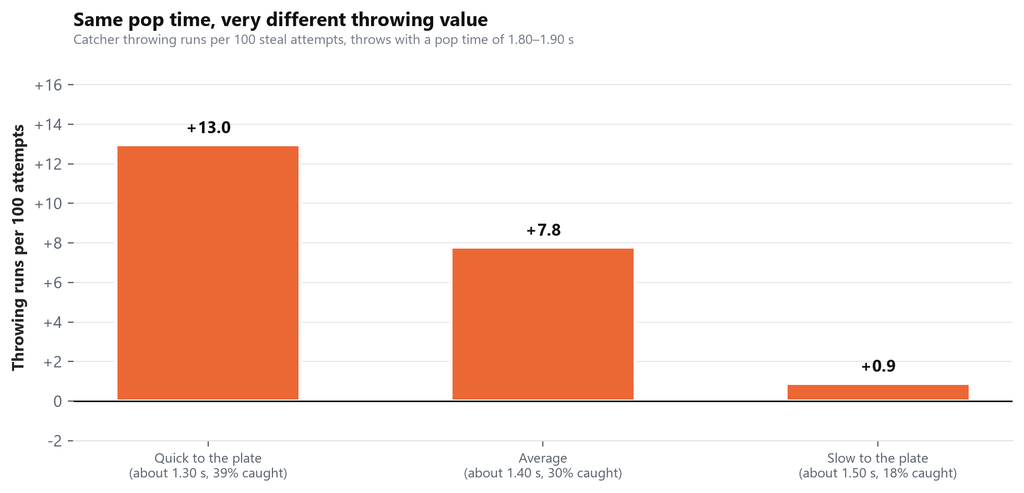

To isolate the pitcher’s part, this compares throws with nearly the same pop time (1.80–1.90 s). Behind quick-to-the-plate pitchers, catchers earn +13.0 throwing runs per 100 attempts; behind slow ones, +0.9. The catcher’s pop time was about the same; the pitcher’s delivery made most of the difference.

So a catcher’s throwing runs partly reflect the staff they catch. When comparing catchers’ throwing, check the time to the plate of the pitchers they worked with, and lean on pop time for the catcher’s own part.

### Throwing up the ladder

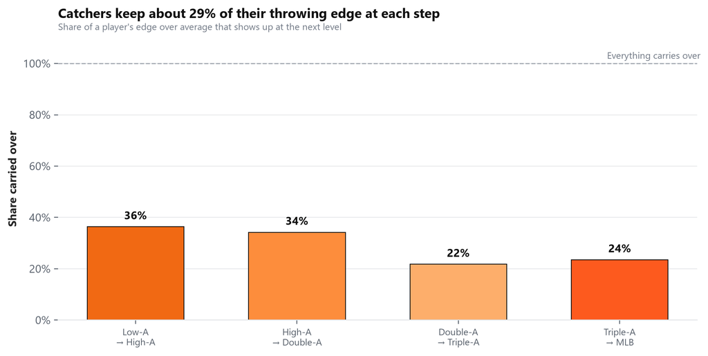

A catcher keeps about 29% of their throwing edge at each step up, about the same as the 32% they keep for framing. Throwing rank holds up less well than framing rank: top-20% throwers are above average at the next level 73% of the time, against 37% for the bottom 20% (for framing, 71% against 19%). A catcher also gets a new pitching staff at every level, which moves their throwing numbers.

- **Pop time gets quicker up the ladder.** The typical catcher’s pop time goes from 1.96 s in Low-A to 1.87 s in MLB, while runners are caught about 20% of the time at every level.
- **Pop time travels better than throwing value.** For the 216 catchers with tracked throws at two neighbouring levels, their pop time at the higher level kept about 67% of its difference from average, against 29% for throwing value. That makes pop time a steadier read on a catcher’s arm than the throwing value.

### Who moves up

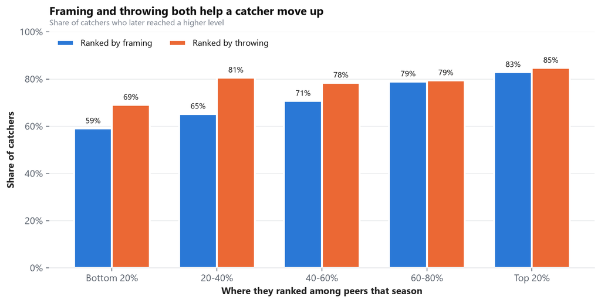

Catchers who rank well at either skill are more likely to move up. By framing, the top 20% moved up 83% of the time against 59% for the bottom 20%. By throwing, it was 85% against 69%. Framing also shows in who reaches MLB: 24% of top-20% framers got there, against 10% of the bottom 20%.

### Catcher takeaways

- Framing separates catchers by about 2.4× as many runs as throwing over a season, but the two are separate skills. Look at both.
- Framing rank is one of the steadiest signals in this report: good framers usually stay good as they climb.
- The pitcher’s time to the plate moves steal outcomes at least as much as pop time does, and it shows up in a catcher’s throwing runs. Judge a catcher’s arm by pop time and in the context of their staff.
- Pop time is a steadier read on a catcher’s arm than the throwing value: it gets quicker up the ladder and carries better from level to level.

## Run Value Translator

If a player saves X runs per 100 chances at one level, what should we expect at a higher level? And what if a position player moves to the position next door? This section answers both, using players who actually made the move.

### Moving up a level

These grids cover any pair of levels, not just the next step up. They use players who played at both levels and compare their full record at each.

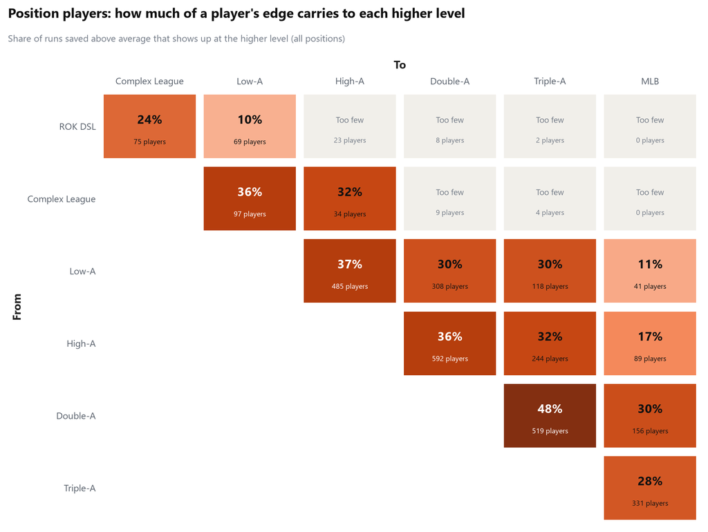

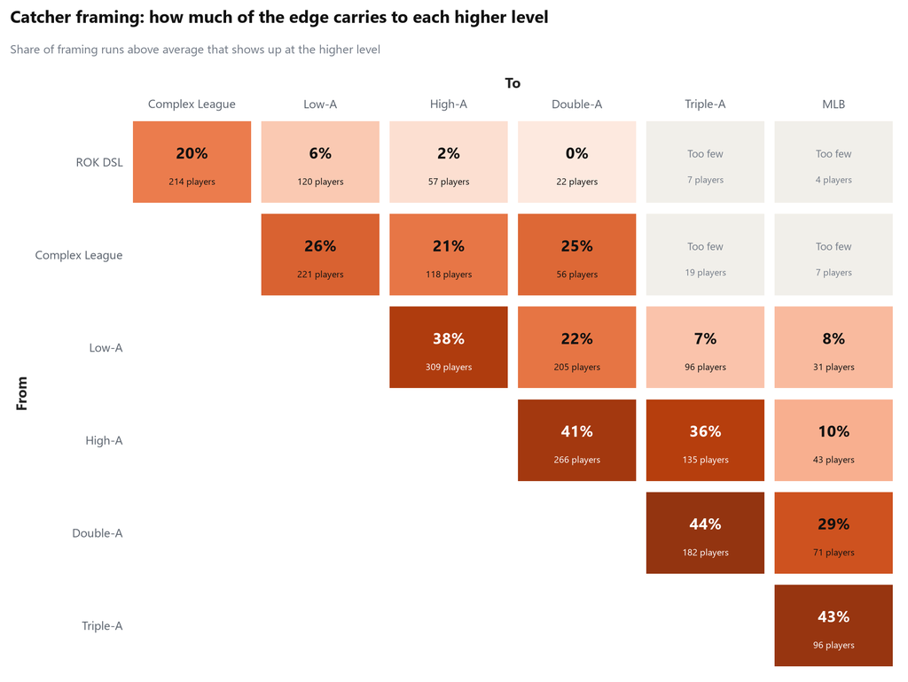

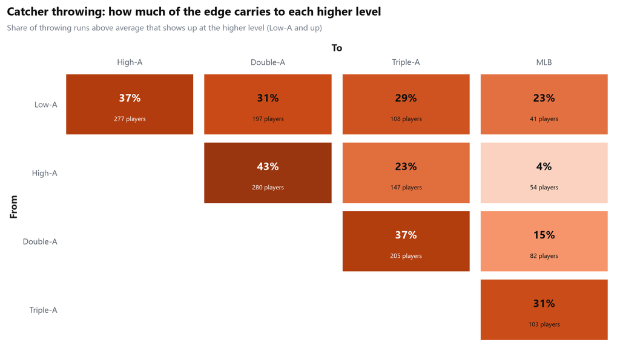

**How to read the grids:** find the level a player is at now on the left, then the level you’re projecting to along the top. A cell reading 30% means a player who is 10 runs per 100 above average should be expected to be about 3 above average at that level. Grey cells don’t have enough players who played at both levels to give a reliable answer.

- **Between full-season levels** (Low-A and up), position players keep about 11%–48% of their edge from one level to any higher one. For example, a position player at +3.0 in Low-A projects to about +0.7 in Double-A.
- **For catchers,** a framer at +0.3 in Triple-A projects to about +0.11 in MLB, and a thrower at +5 runs per 100 steal attempts in Double-A projects to about +1.6 in Triple-A.
- **Rookie-ball numbers barely translate.** Only 8 position players in the data played at both ROK DSL and Double-A, too few to say anything. For the 22 catchers who did, DSL framing provided essentially no information about their Double-A framing.
- **By position:** the calculator below can also translate one position at a time. Splitting by position leaves fewer players per cell, so only 43 of the 147 position-and-level combinations have enough players to translate.

### Moving down a level

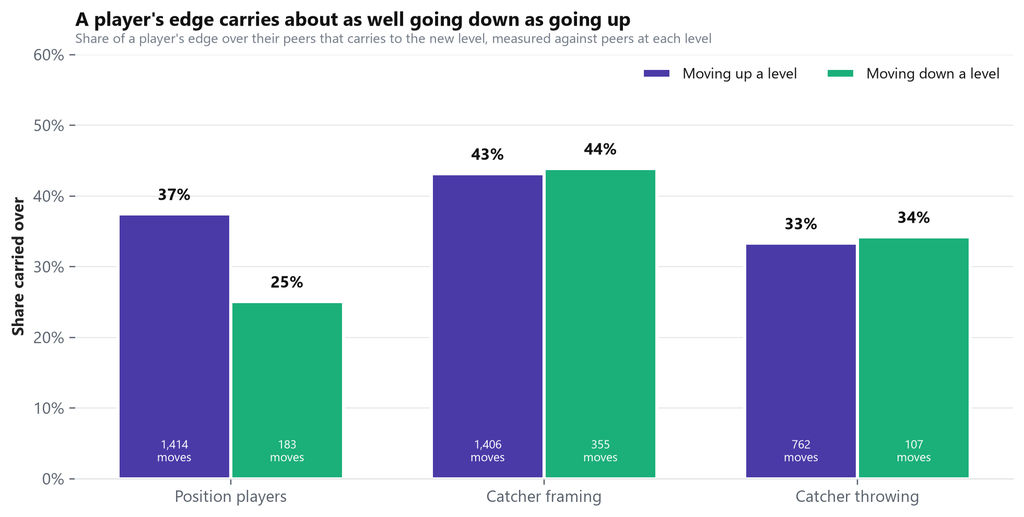

The same check works in reverse, using players who were sent down a level (183 position player moves, 128 of them from MLB to Triple-A, and 355 catcher framing moves). To compare fairly, the chart measures each player against their peers at each level, because the spread of raw numbers is wider at lower levels.

- **Catchers keep about the same share either way:** about 43% of their framing edge going up and 44% going down, and about 33% and 34% for throwing.
- **Position players keep a little less going down** (25% against 37%), on a smaller sample made up mostly of players sent down from MLB.
- **Good defenders stay good after a demotion.** Catchers who were top-20% framers before being sent down were above average at the lower level 87% of the time.

If facing tougher competition were what shrinks a player’s edge, players moving down would keep more of theirs. They keep about the same share (position players even a little less). That points to the main reason the edge shrinks after any move: only about a third of one season’s number reflects lasting skill, and the rest doesn’t repeat, whichever direction the player goes. So a translation should pull a number toward average by about the same amount up or down the ladder.

### Switching to a neighbouring position

| Switch | Players | Same players’ change | Edge that carries over |
| --- | --- | --- | --- |
| 2B → SS | 115 | -0.5 | 39% |
| SS → 2B | 115 | +0.5 | 31% |
| SS → 3B | 52 | +1.5 | 42% |
| 3B → SS | 52 | -1.5 | 45% |
| LF → CF | 174 | -1.5 | 37% |
| CF → LF | 174 | +1.5 | 29% |
| CF → RF | 229 | +1.7 | 38% |
| RF → CF | 229 | -1.7 | 37% |

This uses players who qualified at two neighbouring positions in the same season and level, so the player and the competition are the same and only the position changes. “Same players’ change” is how much better or worse those players did at the new spot, in runs per 100 chances. “Edge that carries over” is how much of a player’s advantage over their peers at the old spot shows up at the new one.

- **The harder spot costs runs.** The same players average about 1.6 runs per 100 chances less in CF than in the corners and 1.5 less at SS than at 3B. The step from 2B to SS is smaller, about 0.5.
- **Some of the edge carries over.** A position player above average at one spot keeps part of that edge at the neighbouring one, but less than half.
- **1B ↔︎ 2B:** only 5 players played both in the same season and level, too few to translate.

### Try it: translate a number

Runs saved per 100 chances Position At level Projected to Playing now Switching to

## What This Means for Player Development

- **Look at rank, not the raw number.** Where a player ranks among their peers tells you more about the next level than their runs-saved total does.
- **Expect big numbers to come down.** A player well above average at one level will usually still be above average at the next, but by less.
- **Be careful with rookie-ball numbers.** They swing the most, and they barely translate to the upper levels.
- **Minor-league framing is a strong signal.** Catchers who frame well in the minors usually keep framing well.
- **Judge a catcher’s arm by pop time, in the context of their staff.** A catcher’s throwing runs rise and fall with how quickly their pitchers get the ball to the plate.
- **Don’t expect promotions to fix defense.** Poor position players keep moving up, so work on defense in the lower levels, while players are still gaining ground.
- **Position changes show up quickly.** Expect a player’s grade to drop at a harder position and rise at an easier one.

## Data and Methods

### Caveats

- **Who’s included.** A position player needs at least 100 chances at one position in a season at a level, and a catcher needs at least 500 called pitches. These cutoffs make sure there’s enough data to include a player-season. They don’t make one season’s number reliable on its own.
- **The MLB comparisons only look back.** They include players who reached MLB with a complete minor-league record. They say nothing about players who were released, stalled, or never reached the cutoffs, and they use a single season (2026), not full careers.
- **Not cause and effect.** The age and position results show patterns, not causes. For example, a team may move a player to an easier position because they were already losing range.
- **Framing only for catchers.** The framing results don’t account for the pitching staff, umpires, or changes in a catcher’s receiving technique.
- **Throwing tracking is thin.** Throwing covers 2016–2026, Low-A to MLB (the source has one combined rookie code, which can’t be split into DSL and Complex League like the rest of this report, so rookie ball is left out). Pop time is tracked on only 11% of steal attempts (2021–2026), arm strength on 21% and the pitcher’s time to the plate on 14%, so the steal model and grid rest on a few thousand attempts.
- **The Position Players section leaves out catchers.** Catchers never reach the 100-chance fielding cutoff, so that section covers the other seven positions, and catchers get their own section.

### Data

The position player data covers 3,136,114 modeled plays by 7,681 players from 2021 to 2026. After the cutoff, that leaves 8,524 player-season-level-position rows (3,038 players). The framing data has 4,767 qualifying catcher-season-level rows (1,466 catchers).

- **Sources:** `queries/play_by_play.sql` (fielding plays), `queries/framing_level_agg.sql` (framing, aggregated in BigQuery from the pitch-level `frv-catching` table), `queries/catcher_throwing.sql` (catcher throwing on stolen-base attempts, from the `xsb` table with level and season added from the catcher-throw play-by-play), and birth dates from `tblPlayer_Pro`.
- **Levels**, in order: ROK DSL, Complex League, Low-A, High-A, Double-A, Triple-A, MLB. The two rookie levels are kept separate because they are different competitive and tracking environments.

### Definitions

- **FRV/100** (“runs saved per 100 chances”): SFG-modeled defensive run value (`-runs_plus_minus`) summed over a player-season at a level and divided by opportunities, times 100. Position player opportunities are modeled plays; framing opportunities are called pitches (`ball_called` / `strike_called`).
- **Percentile** (“rank among peers”): the percentile rank of FRV/100 within the same season and level (and, for position players, position).
- **Spread**: the 90th minus the 10th percentile of FRV/100 at a level. For position players it goes from 11.47 in ROK DSL to 5.03 in MLB. For framing it goes from 1.12 to 0.30. The median qualified player has 118 fielding chances in ROK DSL against 218 in MLB, and a catcher sees 1,142 called pitches against 3,668, which is part of why the lower levels are noisier.

### How reliable are these numbers?

The rates in this report (fielding runs per 100 chances, framing runs per 100 called pitches, throwing runs per 100 steal attempts) mix two things: the player’s real skill and chance. Reliability is the share that reflects the player. At 50%, a rate is half signal and half noise; the more chances behind it, the higher it gets.

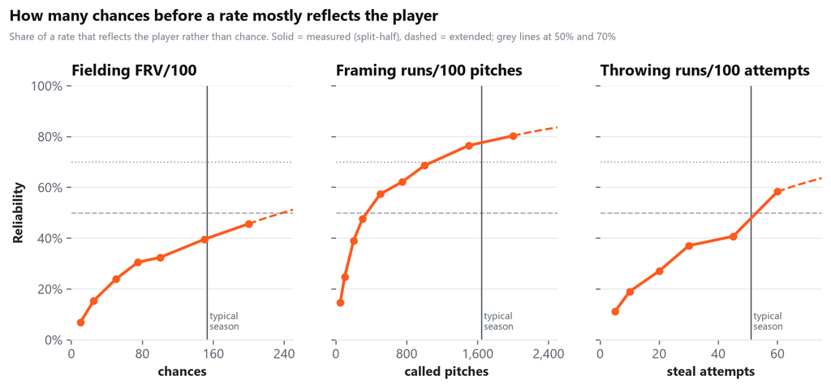

| Measure | 50% reliable at | 70% reliable at | At the cutoff | Typical qualifying season | Next season (r) |
| --- | --- | --- | --- | --- | --- |
| Fielding FRV/100 | 238* chances | 554* | 32% (100) | 40% (153) | 0.33 |
| Framing runs/100 pitches | 349 called pitches | 1,086 | 57% (500) | 78% (1,642) | 0.44 |
| Throwing runs/100 attempts | 53 steal attempts | 100* | 37% (30) | 48% (51) | 0.36 |

* Past the largest sample measurable, so extended (see below).

- **A single season of FRV/100 is mostly noise.** A position player needs about 238* chances for the rate to be half signal. A typical qualifying season (153 chances) is about 40% reliable, and the report’s 100-chance cutoff about 32%. That’s why this report leans on rank and on pooled records, and why a single season’s number should be pulled well toward average before it’s used to judge a player.
- **Framing gets enough pitches within a season.** It reaches 50% at about 349 called pitches, and a catcher sees far more than that, so a typical season (1,642 pitches) is about 78% reliable. But it repeats less from one season to the next (r = 0.44) than that suggests. Pitches within a season share the same pitching staff, umpires and parks, so part of what looks like a catcher’s skill within a season is their situation, and it changes when the situation does.
- **Throwing is about half signal in a typical season.** It takes about 53 steal attempts to reach 50%, about as many as a catcher faces in a typical season (51). Pop time, which is measured directly on each throw, is a steadier read on the arm (see Catchers).
- **Season to season,** a player’s rate (against their peers) correlates 0.33 for fielding, 0.44 for framing and 0.36 for throwing. Those are in line with the roughly one-third carry-over between levels: most of the shrinking after a move is the noise in one season’s number washing out.

**How it’s measured:** for each sample size, the analysis takes player-seasons with at least twice that many chances, put their chances in random order, and correlate the rate over the first half with the rate over the second half across players, each half measured against peers at the same level and season (and position, for position players). That correlation is the reliability of a rate based on that many chances. Values between measured sizes are interpolated. Beyond the largest size with at least 30 players, the curve is extended from the largest measured point with the Spearman–Brown formula (marked with *), which assumes the next chances behave like the earlier ones and may run a little high. Season to season uses each player’s rate against peers in consecutive seasons (same position for position players), with seasons at several levels combined. The framing split uses `queries/framing_split_half.sql`, which orders each catcher-season’s pitches randomly in BigQuery.

### How carry-over is measured

For each pair of consecutive stints one level apart (a stint is a player’s season at a level, ordered by its first and last game dates, so a demotion in the middle of a season isn’t mistaken for a promotion), a linear regression of next-level FRV/100 on current-level FRV/100 is fit separately for each step up the ladder. The slope measures how differences in observed FRV/100 translate between levels; it’s what the charts above show as the “share carried over”. 1.0 would mean a difference carries over in full, and 0 would mean no relationship. Position player slopes run 0.22–0.39 (average 0.30), and framing slopes run 0.26–0.41 (average 0.32). Steps with fewer than 30 position player pairs or 20 catcher pairs aren’t fit.

**Does the narrowing spread explain the drop?** Because each level’s spread is narrower than the one below, a player who keeps exactly the same rank will still show a smaller raw number. To check, FRV/100 was standardized to a z-score within each season and level before refitting (orange bars below).

- **Position players:** the average slope barely moves (0.30 → 0.33), so nearly all of the drop is real regression.
- **Framing:** the average slope rises (0.32 → 0.43), so part of the raw drop reflects the narrowing scale. The slopes still stay well below 1.0.

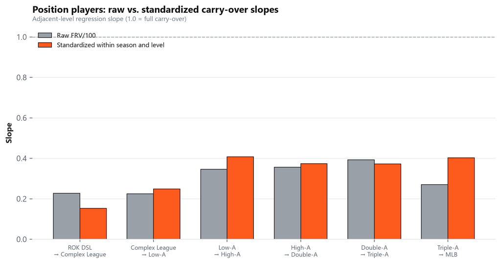

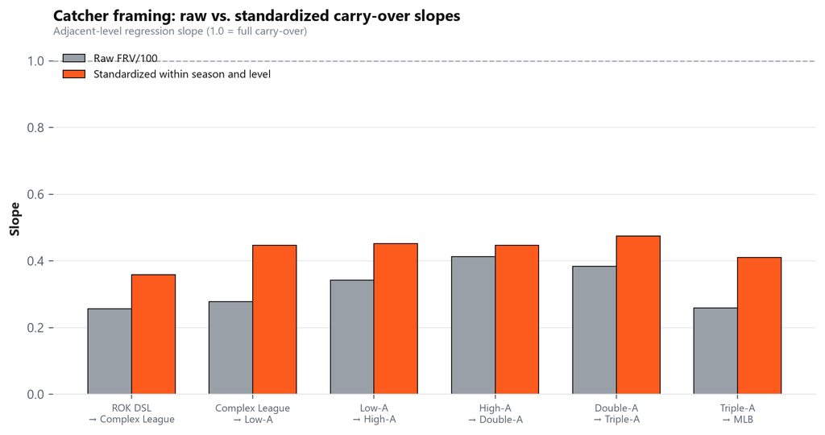

**Rank persistence.** The same back-to-back pairs are grouped by their lower-level percentile (in 20-point bands). For each band, the analysis counts the share finishing above the 50th percentile and above the 80th percentile at the next level. Top-20% position players stay in the top 20% 35% of the time (bottom-20%: 10%). For catchers it’s 33% (bottom-20%: 7%).

### MLB comparison group

The comparison group is players in the most recent MLB season (2026) who qualified at two or more distinct minor-league levels before their first MLB game and debuted after 2022. Play-by-play data starts in 2021, so earlier debuts would have incomplete histories. Minor-league games after the debut, including rehab assignments, are excluded. That leaves 80 position players (47 above average) and 39 catchers (26 above average). MLB rank is within position for position players.

The “above average in the minors” share uses each player’s average minor-league percentile. Across everyone in the group, the correlation between average minor-league percentile and current MLB percentile is modest: 0.26 for position players and 0.32 for catchers. That’s why the article says a strong minor-league record improves the odds rather than settles the question.

### Run Value Translator

For every pair of levels, the analysis selects players with a qualifying record at both (for position players, at the same position) whose first game at the higher level came after their first game at the lower one. Each player’s seasons at a level are pooled into one record, which must meet the usual cutoff (100 chances for position players, 500 called pitches for catchers). A straight line was then fit to the higher-level rate using the lower-level rate.

- The percentage in each cell is the slope. A projection is intercept + slope × the lower-level rate, so it also reflects any difference in average between the two groups.
- Pairs with fewer than 30 position players or 20 catchers are left blank. The same applies to the by-position translations, which are fit separately for each position on players who played that position at both levels.
- **Catcher throwing** uses throwing runs per 100 steal attempts (measured against the average attempt at that level and season), with at least 30 attempts at each level, Low-A and up.
- **Position switches** use players who qualified at two neighbouring positions (1B–2B, 2B–SS, SS–3B, LF–CF, CF–RF) in the same season and level, fitting FRV/100 at the new position on FRV/100 at the old one, separately in each direction. Levels are pooled, so the translation doesn’t depend on level.
- The calculator’s likely range is the projection ± 1.28 residual standard deviations, which covers about 80% of players. Records here pool all seasons at a level, so a single season will usually be noisier than that range suggests.
- Fitting each pair directly avoids chaining the step-by-step results, which would multiply every step’s regression and understate how much carries over across several levels.

### Who moves up

For every qualified minor-league season through 2024, the analysis checks whether the player later appeared at a higher level (a stint there that started after this one did, at any position, with any number of chances) and whether they appeared in MLB. Going by dates means a player sent down in the middle of a season isn’t counted as moving up because of where they started the year. Ending in 2024 gives every player at least 2 more seasons to move up. Seasons after a player’s first MLB season are left out, so veterans sent back to the minors don’t count as “reaching” MLB. Rank is the same within-level percentile used elsewhere. That leaves 3,813 position player seasons and 2,558 catcher seasons.

This also matters for the rank persistence results. Those only include players who were promoted, so if poor position players were rarely promoted, the results would describe a select group. Because most poor position players do move up, that selection effect is small for position players. It is larger for catchers.

### Catcher throwing

Each row is a stolen-base attempt (steals of second and third) at Low-A to MLB. The catcher’s value is the stolen-base model’s `catcher_runs_plus_minus`, which covers nearly every attempt (the throw model’s value only exists on attempts with a tracked throw, and correlates 0.98 with it where both exist). As with framing, throwing runs are `-runs_plus_minus`, so positive means runs saved by the catcher. The model’s catcher, pitcher and baserunner values for an attempt are nearly identical (correlation above 0.99): each is close to the full value of the attempt rather than a split of it, which is why the pitcher’s delivery shows up in the catcher’s number. Pop times outside 1.6–2.4 s, times to the plate outside 1.1–1.8 s runner speeds outside 22–32 ft/s and arm strengths outside 60–95 mph are treated as tracking errors and dropped.

- **Framing vs. throwing:** for catcher-seasons at a level with a qualifying framing season (500+ called pitches) and any steal attempts, the standard deviation of season framing runs is compared with that of season throwing runs. Throwing’s share is its variance over the sum of both variances. Throwing’s spread includes more noise, since a season has only a few dozen attempts.
- **Steal model:** a logistic regression of caught stealing on the catcher’s pop time and arm strength, the pitcher’s time to the plate, runner sprint speed and level, on the 4,728 steals of second where all four were tracked. Arm strength on its own uses the 40,719 steals of second where it was tracked, split into four equal groups. The effects quoted are average marginal effects for one standard deviation. The grid uses the 4,769 steals of second with both pop time and time to the plate tracked; cells with fewer than 50 attempts are left blank.
- **Pitcher effect:** throws with a pop time of 1.80–1.90 s, split into thirds by the pitcher’s time to the plate.
- **Across levels:** catcher-season-level throwing needs 30+ steal attempts; carry-over and rank persistence use the same method as framing, on throwing runs per 100 attempts. Pop time carry-over uses catchers with 10+ tracked throws at two neighbouring levels (slope 0.67, correlation 0.50, 216 catchers). Season to season at any level, a catcher’s average pop time correlates 0.34 with the next season (234 catchers with 10+ tracked throws in both).

### Age

**Age** is as of July 1 of the season (whole years).

**Runs saved at each age:** total runs saved divided by total chances for all qualifying player-seasons at that age, across all levels. This means seasons with more chances count more. Ages with fewer than 30 player-seasons are left out, and the band is a 95% bootstrap interval from resampling players. The peak and low point quoted in the text leave out ages where most seasons are in the two rookie levels. Qualifying position players average slightly above zero overall, so the shape matters more than where the line sits relative to zero.

**Keeping pace with peers:** this chart uses pairs of consecutive seasons by the same player at the same position, at **any level** (3,069 pairs), so players who move up are kept. The outcome is the player’s percentile within season, level and position in the second season.

Chaining raw percentile changes would be misleading. Players who qualify in two seasons in a row were above average the first year and drift back toward the middle the next, whatever their age. A weighted regression therefore uses next-season percentile as the outcome, with age (one term per age), the starting percentile (centered at 50), and whether the player moved up or down a level:

- Each bar is the age term minus 50: the expected change for a player who starts at the median and stays at the same level.
- Weights are the harmonic mean of the two seasons’ chances. Only ages with at least 40 pairs are shown (17–33).
- About 38% of a player’s distance from the median carries into the next season. Moving up a level costs 2.2 rank points on top of that.
- The error bars are 95% bootstrap intervals from resampling players.

Rank is relative to peers who are also aging and moving up, so this shows whether a position player keeps pace with their competition, not how their absolute fielding changes. If everyone in a peer group improved at the same rate, none of them would change rank, so that kind of improvement doesn’t show up here.

### Position

- **Position spread:** 3B has the widest spread (9.13) and LF the narrowest (6.11). Positions are ordered along the traditional defensive spectrum: SS, CF, 2B, 3B, RF, LF, 1B.
- **Two positions in one season:** 844 player-seasons in which a player qualified at exactly two positions in the same season and level. The harder position graded worse 63% of the time, by an average of 11 percentile points. The largest gap among pairings with 50+ cases was CF compared with RF (23 points, 193 cases).
- **Position changes:** a player’s primary position each season is the qualified position with the most chances. 1,405 season-to-season changes in primary position were found, and 59% were moves toward the easier end of the spectrum.

### Last Data Update

2026-09-26.

### Code and Queries

GitHub repository: isardinasfg/defensive-run-value-translations.